# Secesh Max 2013

This set of R scripts processes logger data for predictive stream temperature modeling Created: 21 Feb 2017 Used for all watersheds and all years by changing the basin names and year paths USGS site: 13310700

Stage setting:

```r
library(timeSeries)
library(lattice)
library(foreign)
library(doBy)
library(qpcR)
library(pls)
library(boot)
library(Hmisc)
library(readxl)
library(lubridate)
library(zoo)
library(car)
library(gvlma)
library(ggplot2)
library(rgdal)
library(raster)
library(RColorBrewer)
library(classInt)
library(uuid)
```

```r
  basin <- "Sec"
  midBasin <- "Secesh"
  longBasin <- "Secesh"
  yrPath <- "13"
  yearPath <- "2013"

  nameBasin <- "Secesh" #this is from the Projects XML list of approved names

  dataPath <- "D:/OneDrive/work/GIS/LST/LST_s12_"
  mainPath <- "D:/OneDrive/work/research/CHaMP/CHaMP_data/"
  metricPath <- "D:/Dropbox/StreamTemperatureModels/"

  var <- "Mx"
  longVar <- "Max"
  dataVar <- "Mx8D" #name of the variable in the logger data
  capVar <- "MAX"

  modelPath <- paste0(mainPath, longBasin, "/", yearPath, "/", longVar, "/")
  gisPath <- "D:/OneDrive/work/research/CHaMP/GIS/coverages/"

  now <- Sys.Date()
  print(now)
```

```
[1] "2017-09-28"
```

This part reads the LST data and gap-fills using a cubic spline function

```r
  LST.in <- read.dbf(paste0(gisPath, "/", midBasin, "/", basin, "_", yrPath, "_LST.dbf"))
  PointID <- LST.in[,1]
  LST.in <- LST.in[,2:47]
  LST.in[LST.in<0.1] = NA

  LST.names<-colnames(LST.in)

  myFunc <- function(x)
    {
      if (is.na(x[1]))
      {
        x[1] <- 13022
      }
      x
    }

  LST.filled <- apply(LST.in, 1, function(x) myFunc(x))
  LST.filled <- as.data.frame(t(LST.filled))


  myFunc2 <- function(x)
    {
      if (is.na(x[46]))
      {
        x[46] <- x[43]
      }
      x
    }


  LST.filled <- apply(LST.filled, 1, function(x) myFunc2(x))
  LST.filled <- as.data.frame(t(LST.filled))

  myFunc3 <- function(x)
    {
      if (is.na(x[46]))
      {
        x[46] <- 12943
      }
      x
    }

  LST.filled <- apply(LST.filled, 1, function(x) myFunc3(x))
  LST.filled <- as.data.frame(t(LST.filled))

  tLST.in <- t(LST.filled)

  tLST.out <- na.spline(tLST.in)
  CLST <- tLST.out*0.02-273.15
  tCLST <- t(CLST)
  CLST.out <- as.data.frame(tCLST)


  CLST.out$PointID <- PointID
  colnames(CLST.out)[1:46] <- LST.names
```

Plot to look

```r
{plot(1:46, CLST.out[114,1:46])
  points(1:46, CLST.out[562, 1:46], pch=16, col="blue")
  points(1:46, CLST.out[100, 1:46], pch=16, col="green")
  points(1:46, CLST.out[1, 1:46], pch=16, col="red")
  points(1:46, CLST.out[800, 1:46], pch=16, col="lightblue")}
```

Write it out

```r
  write.dbf(CLST.out, file = paste0(mainPath, longBasin, "/", "LST", yrPath, "_", basin, "_interp.dbf"))
```

This part calculates the zonal mean of the daily LST for each RCA

```r
out_Preds <- read.dbf(paste0(mainPath, longBasin, "/", "LST", yrPath, "_", basin, "_interp.dbf"))


  weights <- read.csv(paste0("../../", basin, "_rca_area_wgts.csv"), stringsAsFactors=FALSE)
  weights[weights$area_wgt<0.01, "area_wgt"] = 0.01

  rcas <- unique(unlist(weights$RCAID))
  rca_zonal <- matrix(ncol=46, nrow=length(rcas))


  l <- 1

  for(i in rcas)
    {
      pixels <- weights[weights$RCAID == i, "GRIDCODE"]
      wgts <- weights[weights$RCAID == i, "area_wgt"]

      for (j in 1:46)
      {
        daily <- out_Preds[out_Preds$PointID %in% pixels, j]
        zonal_mn <- weighted.mean(daily, wgts, na.rm = TRUE)
        rca_zonal[l,j] <- zonal_mn
      }
      l <- l+1
    }


  colnames(rca_zonal)[1:46] <- colnames(out_Preds)[1:46]
  rca_zonal <- as.data.frame(rca_zonal)
  rca_zonal$RCAID <- rcas
```

Plot to look

```r
  plot(1:46, rca_zonal[1,1:46])
  plot(1:46, rca_zonal[100,1:46])
  write.dbf(rca_zonal, file = paste0("LST", yrPath, "_", basin, "_RCA.dbf"))
```

Write out rca_zonal

```r
  write.dbf(rca_zonal, file = paste0("../../", "LST", yrPath, "_", basin, "_RCA.dbf"))
```

Discharge data formatting

```r
  Dv.in <- read.csv(paste0("../", basin, "_dv_data_", yearPath, ".csv"), stringsAsFactors = FALSE)

  dates <- matrix(nrow=365, ncol=1)
  dates[,1] <- 1:365
  colnames(dates) <- c("Days")

  Dv.8Day.out <- data.frame (mup = NULL)


      Dv.site <- Dv.in
      full.year <- merge(dates, Dv.site, by.x = "Days", by.y = "JulDay", all.x = TRUE)

      eightday <- rollapply(full.year$Dv, width = 8, FUN = mean, na.rm = T, fill = NA, align = c("left"))
      eightday <- as.matrix(eightday)
      full.year$Dv8D<- eightday
      full.year$Dv8D[361] <- mean(full.year$Dv[361:365 ])

      Dv.8Day.out <- rbind(Dv.8Day.out, full.year)


  ind <- apply(Dv.8Day.out, 1, function(x) !any(is.na(x)))
  Dv.8Day.out <- Dv.8Day.out[ind,]

write.csv(Dv.8Day.out, paste0("../", basin, "_", yearPath, "_Dv_8Day", ".csv"), row.names = FALSE)
```

Model building

```r
  Log.in <- read.csv(paste0("../../", basin, "_logger_8D_", yearPath, ".csv"), stringsAsFactors = FALSE)

  ID.in <- read.csv(paste0("../../", basin, "_sites_elev.csv"), stringsAsFactors = FALSE)

  LST.in <- read.dbf(paste0("../../", "LST", yrPath, "_", basin, "_RCA.dbf"))
  colnames(LST.in)<-gsub("X", "", colnames(LST.in))
  newnamesnum <- as.numeric(colnames(LST.in)[1:46]);
  Dv.in <- read.csv(paste0("../", basin, "_", yearPath, "_Dv_8Day", ".csv"), stringsAsFactors = FALSE)

  Dv.in <- Dv.in[,c("Dv8D", "Days")]

  LST.Log.out <- data.frame (mup = NULL)
  SiteID <- unique(Log.in$SiteName)

  for (i in SiteID)
    {
      Log.site <- Log.in[Log.in$SiteName  == i,]
      Log.site <- as.data.frame(Log.site)

      RCAID <- ID.in$RCAID[ID.in$SiteName == i]

      Elev <- ID.in$Elev[ID.in$SiteName == i]

      LST.site <- matrix(ncol=3, nrow=46)
      LST.site[,1] <- as.numeric(unlist(colnames(LST.in)[1:46]))
      LST.site[,2] <- unlist(LST.in[LST.in$RCAID == RCAID, 1:46])
      LST.site <- data.frame(LST.site)
      colnames(LST.site) <- c("JulDay", "LST", "Elev")
      LST.site[3] <- Elev
      LST.Log.site <- merge(LST.site, Log.site, by = "JulDay", all.x=TRUE, all.y = FALSE)
      LST.Log.site <- merge(LST.Log.site, Dv.in, by.x = "JulDay", by.y = "Days", all.x=TRUE, all.y+FALSE)

      LST.Log.out <- rbind(LST.Log.out, LST.Log.site)

    }

  Dv <- unlist(LST.Log.site$Dv8D)

  ind <- apply(LST.Log.out, 1, function(x) !any(is.na(x)))
  NoNA.xyz <- LST.Log.out[ind,]

  NoNA.xyz <- NoNA.xyz[,c(dataVar, "LST", "JulDay", "Elev", "Dv8D", "SiteName")]
  colnames(NoNA.xyz) <- c("y", "x", "z", "e", "d", "SiteName")

  write.csv(x=NoNA.xyz, file= paste0(basin, "_", yearPath, "_8Day_", var, "_model_data.csv"), row.names = FALSE)
  NoNA.xyz <- read.csv(paste0(basin, "_", yearPath, "_8Day_", var, "_model_data.csv"), stringsAsFactors = FALSE)

  NoNA.xyz <- orderBy(~z, NoNA.xyz)
  maxrow <- which.max(NoNA.xyz$y)
  data.sp <- NoNA.xyz[1:(maxrow-1),]
  rownames(data.sp) <- 1:dim(data.sp)[1]
  data.fall <- NoNA.xyz[maxrow:nrow(NoNA.xyz),]
  rownames(data.fall) <- 1:dim(data.fall)[1]
```

Correlation matrix

```r
cor.full <- NoNA.xyz[1:5]
cor(cor.full)
```

```
            y           x           z           e           d
y  1.00000000  0.92394023  0.02770359 -0.01753057  0.07249107
x  0.92394023  1.00000000  0.03738555 -0.04625968  0.19734845
z  0.02770359  0.03738555  1.00000000 -0.08426542 -0.29189346
e -0.01753057 -0.04625968 -0.08426542  1.00000000  0.03090946
d  0.07249107  0.19734845 -0.29189346  0.03090946  1.00000000
```

Spring

```r
cor.sp <- data.sp[1:5]
cor(cor.sp)
```

```
            y           x             z             e            d
y  1.00000000  0.94279881  0.9356578391 -0.0802033710  0.065964923
x  0.94279881  1.00000000  0.9313514395 -0.0951957791  0.228880389
z  0.93565784  0.93135144  1.0000000000 -0.0001239658  0.209177097
e -0.08020337 -0.09519578 -0.0001239658  1.0000000000 -0.000663084
d  0.06596492  0.22888039  0.2091770967 -0.0006630840  1.000000000
```

Fall

```r
cor.fall <- data.fall[1:5]
cor(cor.fall)
```

```
            y           x            z           e            d
y  1.00000000  0.89960193 -0.913323416  0.02105079 -0.208844312
x  0.89960193  1.00000000 -0.925738242 -0.02017226 -0.135498217
z -0.91332342 -0.92573824  1.000000000 -0.07614293  0.002693825
e  0.02105079 -0.02017226 -0.076142926  1.00000000 -0.025506937
d -0.20884431 -0.13549822  0.002693825 -0.02550694  1.000000000
```

plot the data

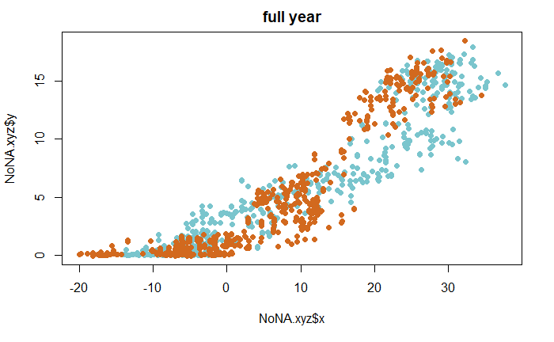

```r
  {plot(NoNA.xyz$x, NoNA.xyz$y, main = "full year")
  points(data.sp$x, data.sp$y, pch=16, col="cadetblue3")
  points(data.fall$x, data.fall$y, pch=16, col="chocolate")}
```

```r
NA
```

#### Full year models

```r
  y <- NoNA.xyz$y
  x <- NoNA.xyz$x
  z <- NoNA.xyz$z
  e <- NoNA.xyz$e
  d <- NoNA.xyz$d

  mod <- lm(y ~ x + I(x^2) + e + d + d*z)
  sum_mod <- summary(mod)
  sum_mod
```

Model prediction

```r
  pred.y <- predict(mod)
  {plot(pred.y, y, main = paste0("8-day ", var, " Full Year"))
  abline(0,1)}
```

Model diagnostics

```r
  post_mod <- summary(lm(y ~ pred.y))
  gvmodel <- gvlma(mod)
  summary(gvmodel)
```

```r
  outlierTest(mod)
```

```r
  qqPlot(mod, main="QQ Plot Full Year")
```

Assumptions:

```r
plot(mod)
```

```r
  spreadLevelPlot(mod)
```

```r
  plot(pred.y, mod$residuals, main="Model diagnostics Full Year", xlab="Predicted", ylab="Residuals")
```

```r
  pressstat_sum <- PRESS(mod, verbose = "FALSE")
  RMSEP <- sqrt(mean((pressstat_sum$residuals)^2))

  library(pls)
  mod2 <- plsr(y ~ x + I(x^2) + e, validation = "LOO")
  p2 <- R2(mod2)
  detach("package:pls", unload=TRUE)

  coeffs <- as.matrix(coefficients(sum_mod))

  pred.out <- matrix(nrow=length(pred.y), ncol=5)
  pred.out[,1] <- y
  pred.out[,2] <- pred.y
  pred.out[,3] <- z
  pred.out[,4] <- "full year"
  pred.out[,5] <- yearPath
  colnames(pred.out) <- c("Y", "PredY", "JulDay", "Season", "Year")
  write.table (x=pred.out,append=F,row.names=F,file=paste0("jk_pred_v_y_", var, "_", basin, "_", yearPath, "_full_year.csv"),sep = ",", col.names=F)
```

```r
  fit <- lm(y~ pred.y)

  summary(fit)
```

Output tables formatting for coeffs and metrics

```r
  coeffs_out <- data.frame(Int=numeric(2), bLST=numeric(2), bLST2=numeric(2), bJul=numeric(2), bElev=numeric(2), bD=numeric(2), bDJul=numeric(2))
  metrics_out <- data.frame(r2=numeric(2), RMSE=numeric(2), p2=numeric(2), RMSEP=numeric(2), N_Sites=numeric(2), N=numeric(2))
  rownames(metrics_out) <- c("Spring", "Fall")
  rownames(coeffs_out) <- c("Spring", "Fall")
```

```r
 # no Julday output
  coeffs_out[1,1] <- coeffs[1,1]
  coeffs_out[1,2] <- coeffs[2,1]
  coeffs_out[1,3] <- coeffs[3,1]
  coeffs_out[1,4] <- 0
  coeffs_out[1,5] <- coeffs[4,1]
  coeffs_out[1,6] <- coeffs[5,1]
  coeffs_out[1,7] <- 0

  metrics_out[1,1] <- sum_mod$adj.r.squared
  metrics_out[1,2] <- sum_mod$sigma
  metrics_out[1,3] <- p2$val[5]
  metrics_out[1,4] <- RMSEP
  metrics_out[1,5] <- length(unique(NoNA.xyz$SiteName))
  metrics_out[1,6] <- length(y)

  coeffs_out[2,1] <- coeffs[1,1]
  coeffs_out[2,2] <- coeffs[2,1]
  coeffs_out[2,3] <- coeffs[3,1]
  coeffs_out[2,4] <- 0
  coeffs_out[2,5] <- coeffs[4,1]
  coeffs_out[2,6] <- coeffs[5,1]
  coeffs_out[2,7] <- 0

  metrics_out[2,1] <- sum_mod$adj.r.squared
  metrics_out[2,2] <- post_mod$sigma
  metrics_out[2,3] <- p2$val[5]
  metrics_out[2,4] <- RMSEP
  metrics_out[2,5] <- length(unique(NoNA.xyz$SiteName))
  metrics_out[2,6] <- length(y)
```

write out full year coeffs

```r
  write.table(x=coeffs_out, append=F,row.names=T, file = paste0("All_data_", basin, "_", yearPath, "_mod_coeffs_", var, ".csv"), sep = ",", col.names=NA)

  write.table(x=metrics_out, append=F,row.names=T, file = paste0("All_data_", basin, "_", yearPath, "_mod_metrics_", var, ".csv"), sep = ",", col.names=NA)
```

****Spring/Fall models*** Spring data model

```r
  coeffs_out <- data.frame(Int=numeric(2), bLST=numeric(2), bLST2=numeric(2), bJul=numeric(2), bElev=numeric(2), bD=numeric(2), bDJul=numeric(2))
  metrics_out <- data.frame(r2=numeric(2), RMSE=numeric(2), p2=numeric(2), RMSEP=numeric(2), N_Sites=numeric(2), N=numeric(2))
  rownames(metrics_out) <- c("Spring", "Fall")
  rownames(coeffs_out) <- c("Spring", "Fall")
```

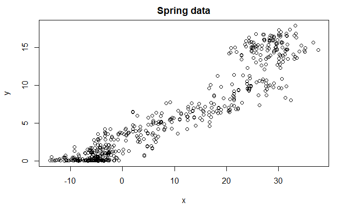

```r
  y <- data.sp$y
  x <- data.sp$x
  z <- data.sp$z
  e <- data.sp$e
  d <- data.sp$d
  plot(x, y, main="Spring data")
```

```r
  mod <- lm(y ~ x + I(x^2) + z + e + d + d*z)
  sum_mod <- summary(mod)
  sum_mod
```

```
Call:
lm(formula = y ~ x + I(x^2) + z + e + d + d * z)

Residuals:
    Min      1Q  Median      3Q     Max
-5.5942 -0.9089  0.1181  0.9660  3.7710

Coefficients:
              Estimate Std. Error t value Pr(>|t|)
(Intercept)  8.854e-01  5.422e-01   1.633  0.10307
x            1.045e-01  2.031e-02   5.149 3.70e-07 ***
I(x^2)       3.778e-03  5.438e-04   6.947 1.09e-11 ***
z            4.568e-02  2.773e-03  16.476  < 2e-16 ***
e           -8.716e-04  2.884e-04  -3.023  0.00263 **
d           -3.414e-04  8.318e-04  -0.410  0.68164
z:d         -4.413e-06  6.138e-06  -0.719  0.47244
---
Signif. codes:  0 ‘***’ 0.001 ‘**’ 0.01 ‘*’ 0.05 ‘.’ 0.1 ‘ ’ 1

Residual standard error: 1.376 on 532 degrees of freedom
Multiple R-squared:  0.9429,    Adjusted R-squared:  0.9423
F-statistic:  1464 on 6 and 532 DF,  p-value: < 2.2e-16
```

#### Model diagnostics

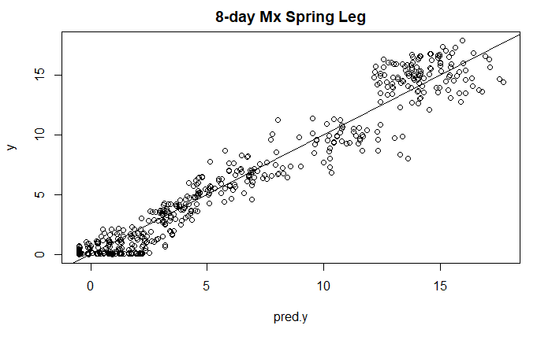

```r
  pred.y <- predict(mod)
  pred.y[pred.y < -0.5] = -0.5
  {plot(pred.y, y, main = paste0("8-day ", var, " Spring Leg"))
  abline(0,1)}
```

Test assumption of linear model

```r
  post_mod <- summary(lm(y ~ pred.y))
  gvmodel <- gvlma(mod)
  summary(gvmodel)
```

```
Call:
lm(formula = y ~ x + I(x^2) + z + e + d + d * z)

Residuals:
    Min      1Q  Median      3Q     Max
-5.5942 -0.9089  0.1181  0.9660  3.7710

Coefficients:
              Estimate Std. Error t value Pr(>|t|)
(Intercept)  8.854e-01  5.422e-01   1.633  0.10307
x            1.045e-01  2.031e-02   5.149 3.70e-07 ***
I(x^2)       3.778e-03  5.438e-04   6.947 1.09e-11 ***
z            4.568e-02  2.773e-03  16.476  < 2e-16 ***
e           -8.716e-04  2.884e-04  -3.023  0.00263 **
d           -3.414e-04  8.318e-04  -0.410  0.68164
z:d         -4.413e-06  6.138e-06  -0.719  0.47244
---
Signif. codes:  0 ‘***’ 0.001 ‘**’ 0.01 ‘*’ 0.05 ‘.’ 0.1 ‘ ’ 1

Residual standard error: 1.376 on 532 degrees of freedom
Multiple R-squared:  0.9429,    Adjusted R-squared:  0.9423
F-statistic:  1464 on 6 and 532 DF,  p-value: < 2.2e-16


ASSESSMENT OF THE LINEAR MODEL ASSUMPTIONS
USING THE GLOBAL TEST ON 4 DEGREES-OF-FREEDOM:
Level of Significance =  0.05

Call:
 gvlma(x = mod)

                     Value   p-value                   Decision
Global Stat        115.360 0.000e+00 Assumptions NOT satisfied!
Skewness             5.442 1.966e-02 Assumptions NOT satisfied!
Kurtosis             3.466 6.263e-02    Assumptions acceptable.
Link Function       44.817 2.163e-11 Assumptions NOT satisfied!
Heteroscedasticity  61.634 4.108e-15 Assumptions NOT satisfied!
```

check for outliers

```r
  outlierTest(mod)
```

```
     rstudent unadjusted p-value Bonferonni p
400 -4.164115         3.6471e-05     0.019658
```

rerun w/o outliers

```r
  mod <- lm(y ~ x + I(x^2) + z + e + d + d*z, data=data.sp[-c(400), ])
```

recheck for outliers

```r
  outlierTest(mod)
```

```
No Studentized residuals with Bonferonni p < 0.05
Largest |rstudent|:
     rstudent unadjusted p-value Bonferonni p
399 -3.783418         0.00017233     0.092712
```

recheck assumptions

```r
  gvmodel <- gvlma(mod)
  summary(gvmodel)
```

```
Call:
lm(formula = y ~ x + I(x^2) + z + e + d + d * z, data = data.sp[-c(400),
    ])

Residuals:
    Min      1Q  Median      3Q     Max
-5.0288 -0.9115  0.1133  0.9495  3.7553

Coefficients:
              Estimate Std. Error t value Pr(>|t|)
(Intercept)  8.164e-01  5.343e-01   1.528  0.12711
x            1.058e-01  2.000e-02   5.289 1.80e-07 ***
I(x^2)       3.891e-03  5.363e-04   7.255 1.43e-12 ***
z            4.502e-02  2.736e-03  16.458  < 2e-16 ***
e           -8.123e-04  2.844e-04  -2.856  0.00446 **
d           -3.441e-04  8.193e-04  -0.420  0.67469
z:d         -4.312e-06  6.046e-06  -0.713  0.47609
---
Signif. codes:  0 ‘***’ 0.001 ‘**’ 0.01 ‘*’ 0.05 ‘.’ 0.1 ‘ ’ 1

Residual standard error: 1.355 on 531 degrees of freedom
Multiple R-squared:  0.9447,    Adjusted R-squared:  0.9441
F-statistic:  1512 on 6 and 531 DF,  p-value: < 2.2e-16


ASSESSMENT OF THE LINEAR MODEL ASSUMPTIONS
USING THE GLOBAL TEST ON 4 DEGREES-OF-FREEDOM:
Level of Significance =  0.05

Call:
 gvlma(x = mod)

                      Value   p-value                   Decision
Global Stat        104.3839 0.000e+00 Assumptions NOT satisfied!
Skewness             2.8590 9.086e-02    Assumptions acceptable.
Kurtosis             0.1992 6.554e-01    Assumptions acceptable.
Link Function       39.8445 2.750e-10 Assumptions NOT satisfied!
Heteroscedasticity  61.4812 4.441e-15 Assumptions NOT satisfied!
```

plot model diagnostics

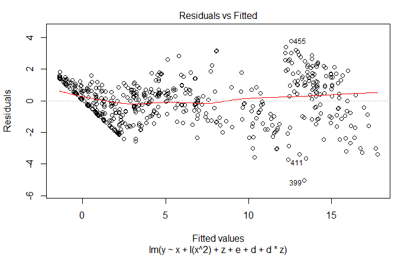

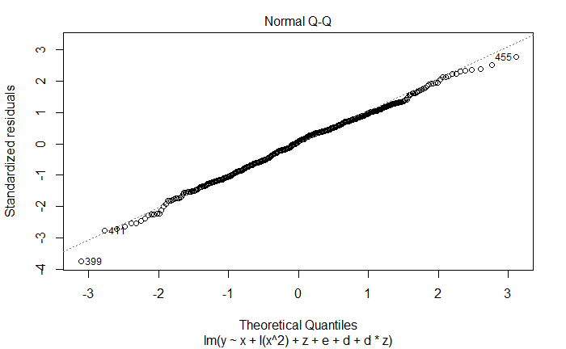

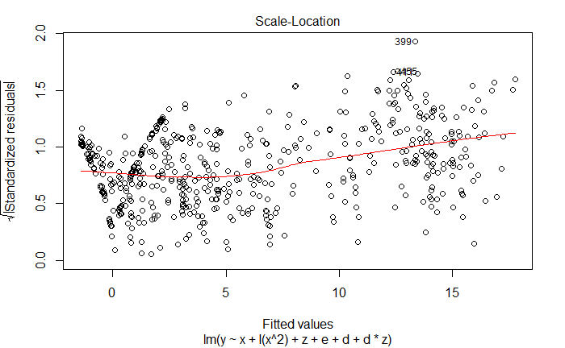

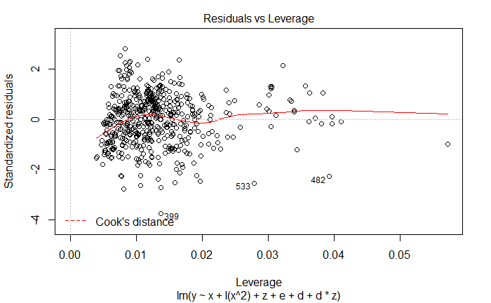

```r
  plot(mod)
```

more tests: qqplot

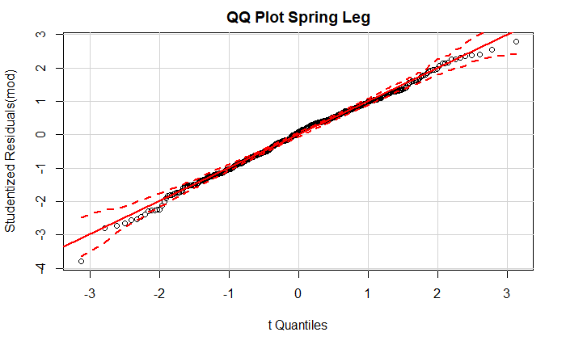

```r
  qqPlot(mod, main="QQ Plot Spring Leg")
```

if outliers need to be removed (otherwise skip)

```r
  data.sp <- data.sp[-c(400), ]
  y <- data.sp$y
  x <- data.sp$x
  z <- data.sp$z
  e <- data.sp$e
  d <- data.sp$d
  mod <- lm(y ~ x + I(x^2) + z + e + d + d*z)
  sum_mod <- summary(mod)
```

format the data for prediction output

```r
  pressstat_sum <- PRESS(sum_mod, verbose = "FALSE")

  coeffs <- as.matrix(coefficients(mod))
  pred.y <- predict(mod)

  pred.y[pred.y < -0.5] = -0.5
```

Look at the residuals

```
68 negative fitted values removed
```

```
Suggested power transformation:  0.7374157
```

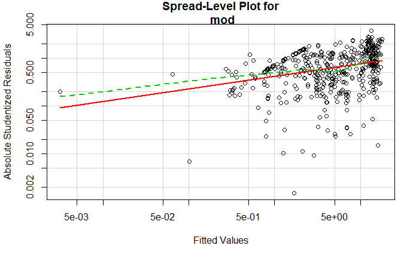

```r
  spreadLevelPlot(mod)
```

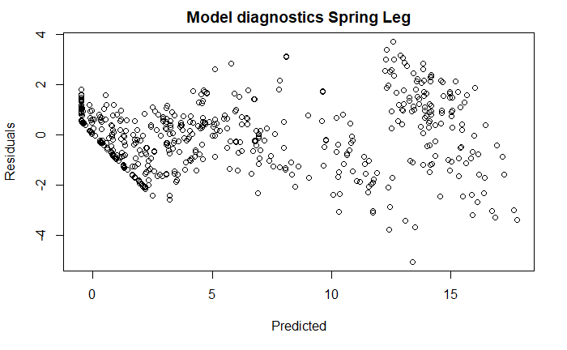

```r
  plot(pred.y, mod$residuals, main="Model diagnostics Spring Leg", xlab="Predicted", ylab="Residuals")
```

LOO PRESS stats

```r
  pressstat_sum <- PRESS(sum_mod, verbose = "FALSE")
  RMSEP <- sqrt(mean((pressstat_sum$residuals)^2))

  library(pls)
  mod2 <- plsr(y ~ x + I(x^2) + z + e + d + d*z , validation = "LOO")
  p2 <- R2(mod2)
  detach("package:pls", unload=TRUE)
```

write out predicted, coeffs, & metrics

```r
  pred.out <- matrix(nrow=length(pred.y), ncol=5)
  pred.out[,1] <- y
  pred.out[,2] <- pred.y
  pred.out[,3] <- z
  pred.out[,4] <- "Spring"
  pred.out[,5] <- yearPath
  colnames(pred.out) <- c("Y", "PredY", "JulDay", "Season", "Year")
  write.table (x=pred.out,append=F,row.names=F,file=paste0("jk_pred_v_y_", var, "_", basin, "_", yearPath, "_sp_fall.csv"),sep = ",", col.names=F)

  coeffs_out[1,1] <- coeffs[1,1]
  coeffs_out[1,2] <- coeffs[2,1]
  coeffs_out[1,3] <- coeffs[3,1]
  coeffs_out[1,4] <- coeffs[4,1]
  coeffs_out[1,5] <- coeffs[5,1]
  coeffs_out[1,6] <- coeffs[6,1]
  coeffs_out[1,7] <- coeffs[7,1]

  metrics_out[1,1] <- sum_mod$adj.r.squared
  metrics_out[1,2] <- sum_mod$sigma
  metrics_out[1,3] <- p2$val[5]
  metrics_out[1,4] <- RMSEP
  metrics_out[1,5] <- length(unique(data.sp$SiteName))
  metrics_out[1,6] <- length(y)
```

Fall data model

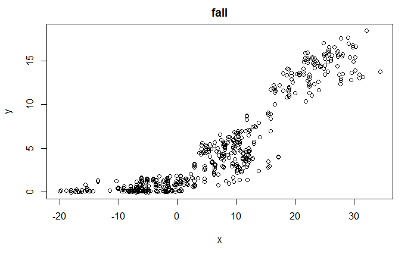

```r
  y <- data.fall$y
  x <- data.fall$x
  z <- data.fall$z
  e <- data.fall$e
  d <- data.fall$d
  plot(x, y, main="fall")
```

```r
  mod <- lm(y ~ x + I(x^2) + z + e + d + d*z)
  sum_mod <- summary(mod)
  sum_mod
```

```
Call:
lm(formula = y ~ x + I(x^2) + z + e + d + d * z)

Residuals:
    Min      1Q  Median      3Q     Max
-6.0465 -0.8958 -0.0240  0.9767  3.6206

Coefficients:
              Estimate Std. Error t value Pr(>|t|)
(Intercept)  2.160e+01  3.161e+00   6.833 2.20e-11 ***
x            7.152e-02  1.460e-02   4.899 1.27e-06 ***
I(x^2)       7.903e-03  4.256e-04  18.567  < 2e-16 ***
z           -5.484e-02  1.074e-02  -5.105 4.55e-07 ***
e           -8.184e-04  2.492e-04  -3.285  0.00109 **
d            1.847e-02  1.395e-02   1.324  0.18607
z:d         -7.614e-05  5.104e-05  -1.492  0.13635
---
Signif. codes:  0 ‘***’ 0.001 ‘**’ 0.01 ‘*’ 0.05 ‘.’ 0.1 ‘ ’ 1

Residual standard error: 1.394 on 553 degrees of freedom
Multiple R-squared:  0.9288,    Adjusted R-squared:  0.928
F-statistic:  1202 on 6 and 553 DF,  p-value: < 2.2e-16
```

#### Model Diagnostics

plot predicted v observed

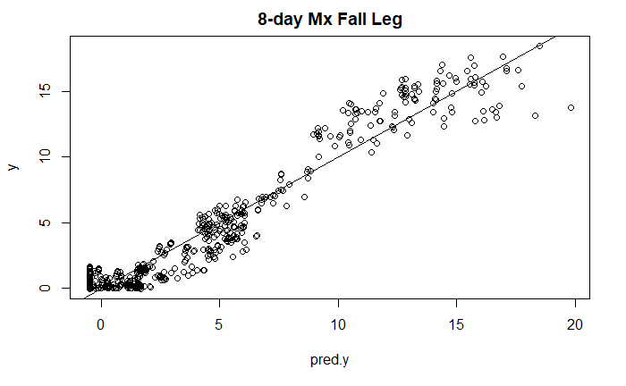

```r
  pred.y <- predict(mod)
  pred.y[pred.y < -0.5] = -0.5
  {plot(pred.y, y, main = paste0("8-day ", var, " Fall Leg"))
  abline(0,1)}
```

Tests of assumptions of linear model

```r
  gvmodel <- gvlma(mod)
  summary(gvmodel)
```

```
Call:
lm(formula = y ~ x + I(x^2) + z + e + d + d * z)

Residuals:
    Min      1Q  Median      3Q     Max
-6.0465 -0.8958 -0.0240  0.9767  3.6206

Coefficients:
              Estimate Std. Error t value Pr(>|t|)
(Intercept)  2.160e+01  3.161e+00   6.833 2.20e-11 ***
x            7.152e-02  1.460e-02   4.899 1.27e-06 ***
I(x^2)       7.903e-03  4.256e-04  18.567  < 2e-16 ***
z           -5.484e-02  1.074e-02  -5.105 4.55e-07 ***
e           -8.184e-04  2.492e-04  -3.285  0.00109 **
d            1.847e-02  1.395e-02   1.324  0.18607
z:d         -7.614e-05  5.104e-05  -1.492  0.13635
---
Signif. codes:  0 ‘***’ 0.001 ‘**’ 0.01 ‘*’ 0.05 ‘.’ 0.1 ‘ ’ 1

Residual standard error: 1.394 on 553 degrees of freedom
Multiple R-squared:  0.9288,    Adjusted R-squared:  0.928
F-statistic:  1202 on 6 and 553 DF,  p-value: < 2.2e-16


ASSESSMENT OF THE LINEAR MODEL ASSUMPTIONS
USING THE GLOBAL TEST ON 4 DEGREES-OF-FREEDOM:
Level of Significance =  0.05

Call:
 gvlma(x = mod)

                    Value   p-value                   Decision
Global Stat        96.776 0.000e+00 Assumptions NOT satisfied!
Skewness            2.663 1.027e-01    Assumptions acceptable.
Kurtosis            4.386 3.623e-02 Assumptions NOT satisfied!
Link Function      54.385 1.648e-13 Assumptions NOT satisfied!
Heteroscedasticity 35.341 2.767e-09 Assumptions NOT satisfied!
```

check for outliers

```r
  outlierTest(mod)
```

```
    rstudent unadjusted p-value Bonferonni p
11 -4.527836         7.3053e-06    0.0040909
```

rerun w/o outliers (if necessary)

```r
  mod <- lm(y ~ x + I(x^2) + z + e + d + d*z, data=data.fall[-c(8,11), ])
```

recheck for outliers

```r
  outlierTest(mod)
```

```
No Studentized residuals with Bonferonni p < 0.05
Largest |rstudent|:
    rstudent unadjusted p-value Bonferonni p
57 -3.087008          0.0021237           NA
```

recheck assumptions

```r
  gvmodel <- gvlma(mod)
  summary(gvmodel)
```

```
Call:
lm(formula = y ~ x + I(x^2) + z + e + d + d * z, data = data.fall[-c(8,
    11), ])

Residuals:
    Min      1Q  Median      3Q     Max
-4.0702 -0.8589 -0.0200  0.8858  3.6109

Coefficients:
              Estimate Std. Error t value Pr(>|t|)
(Intercept)  2.103e+01  3.067e+00   6.855 1.91e-11 ***
x            7.612e-02  1.418e-02   5.368 1.17e-07 ***
I(x^2)       8.512e-03  4.246e-04  20.046  < 2e-16 ***
z           -5.386e-02  1.042e-02  -5.170 3.29e-07 ***
e           -8.157e-04  2.417e-04  -3.374 0.000792 ***
d            1.616e-02  1.353e-02   1.194 0.232913
z:d         -6.589e-05  4.952e-05  -1.331 0.183892
---
Signif. codes:  0 ‘***’ 0.001 ‘**’ 0.01 ‘*’ 0.05 ‘.’ 0.1 ‘ ’ 1

Residual standard error: 1.352 on 551 degrees of freedom
Multiple R-squared:  0.9326,    Adjusted R-squared:  0.9319
F-statistic:  1271 on 6 and 551 DF,  p-value: < 2.2e-16


ASSESSMENT OF THE LINEAR MODEL ASSUMPTIONS
USING THE GLOBAL TEST ON 4 DEGREES-OF-FREEDOM:
Level of Significance =  0.05

Call:
 gvlma(x = mod)

                      Value   p-value                   Decision
Global Stat        93.92568 0.000e+00 Assumptions NOT satisfied!
Skewness            0.22448 6.356e-01    Assumptions acceptable.
Kurtosis            0.09998 7.518e-01    Assumptions acceptable.
Link Function      69.27071 1.110e-16 Assumptions NOT satisfied!
Heteroscedasticity 24.33051 8.114e-07 Assumptions NOT satisfied!
```

plot model diagnostics

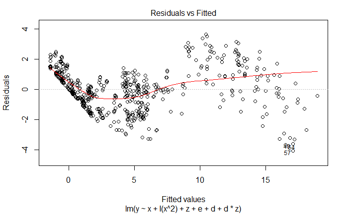

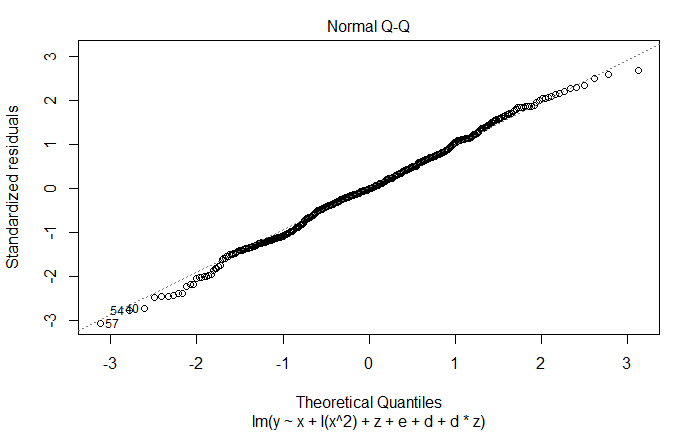

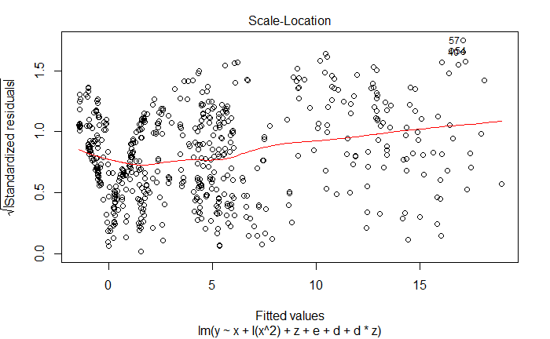

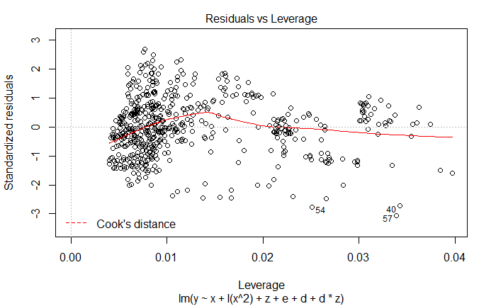

```r
  plot(mod)
```

more diagonstics: qqplot

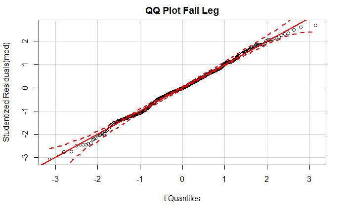

```r
  qqPlot(mod, main="QQ Plot Fall Leg")
```

if outliers need to be removed (otherwise skip)

```r
  data.fall <- data.fall[-c(8,11), ]
  y <- data.fall$y
  x <- data.fall$x
  z <- data.fall$z
  e <- data.fall$e
  d <- data.fall$d
  mod <- lm(y ~ x + I(x^2) + z + e + d + d*z)
  sum_mod <- summary(mod)
```

format the data for prediction output

```r
  pressstat_sum <- PRESS(sum_mod, verbose = "FALSE")

  coeffs <- as.matrix(coefficients(mod))
  pred.y <- predict(mod)

  pred.y[pred.y < -0.5] = -0.5
```

LOO PRESS stats

```r
  pressstat_sum <- PRESS(sum_mod, verbose = "FALSE")
  RMSEP <- sqrt(mean((pressstat_sum$residuals)^2))

  library(pls)
  mod2 <- plsr(y ~ x + I(x^2) + z + e + d + d*z, validation = "LOO")
  p2 <- R2(mod2)
  detach("package:pls", unload=TRUE)
```

write out predicted, coeffs, & metrics

```r
  pred.out <- matrix(nrow=length(pred.y), ncol=5)
  pred.out[,1] <- y
  pred.out[,2] <- pred.y
  pred.out[,3] <- z
  pred.out[,4] <- "fall"
  pred.out[,5] <- yearPath

  write.table (x=pred.out,append=T,row.names=F,file=paste0("jk_pred_v_y_", var, "_", basin, "_", yearPath, "_sp_fall.csv"),sep = ",", col.names=F)

  coeffs_out[2,1] <- coeffs[1,1]
  coeffs_out[2,2] <- coeffs[2,1]
  coeffs_out[2,3] <- coeffs[3,1]
  coeffs_out[2,4] <- coeffs[4,1]
  coeffs_out[2,5] <- coeffs[5,1]
  coeffs_out[2,6] <- coeffs[6,1]
  coeffs_out[2,7] <- coeffs[7,1]

  metrics_out[2,1] <- sum_mod$adj.r.squared
  metrics_out[2,2] <- post_mod$sigma
  metrics_out[2,3] <- p2$val[5]
  metrics_out[2,4] <- RMSEP
  metrics_out[2,5] <- length(unique(data.fall$SiteName))
  metrics_out[2,6] <- length(y)
```

write it out

```r
  write.table(x=coeffs_out, append=F,row.names=T, file = paste0("All_data_", basin, "_", yearPath, "_mod_coeffs_", var, ".csv"), sep = ",", col.names=NA)

  write.table(x=metrics_out, append=F,row.names=T, file = paste0("All_data_", basin, "_", yearPath, "_mod_metrics_", var, ".csv"), sep = ",", col.names=NA)
```

plot the full year of predicted v observed

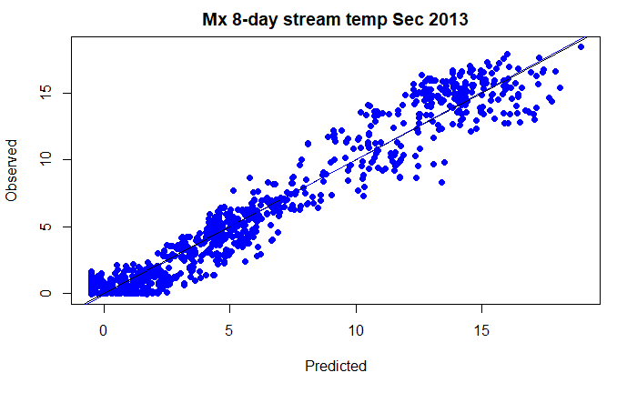

```r
  pred.y <- read.csv(paste0("jk_pred_v_y_", var, "_", basin, "_", yearPath, "_sp_fall.csv"), stringsAsFactors = FALSE, header = FALSE)
  colnames(pred.y) <- c("Y", "PredY", "JulDay", "Season", "Year")

  {plot(pred.y$PredY, pred.y$Y, pch=16, col="blue", main=paste0(var, " 8-day stream temp ", basin, " ", yearPath), xlab="Predicted", ylab="Observed")
  abline(0,1)
  abline(lm(pred.y$Y~ pred.y$PredY), col="blue")}
```

full year fit metrics

```r
  fit <- lm(pred.y$Y~ pred.y$PredY)

  summary(fit)
```

```
Call:
lm(formula = pred.y$Y ~ pred.y$PredY)

Residuals:
    Min      1Q  Median      3Q     Max
-5.0935 -0.8350  0.0843  0.7605  3.6899

Coefficients:
              Estimate Std. Error t value Pr(>|t|)
(Intercept)  -0.105697   0.056350  -1.876    0.061 .
pred.y$PredY  1.011524   0.007501 134.857   <2e-16 ***
---
Signif. codes:  0 ‘***’ 0.001 ‘**’ 0.01 ‘*’ 0.05 ‘.’ 0.1 ‘ ’ 1

Residual standard error: 1.305 on 1091 degrees of freedom
Multiple R-squared:  0.9434,    Adjusted R-squared:  0.9434
F-statistic: 1.819e+04 on 1 and 1091 DF,  p-value: < 2.2e-16
```

This part applies the model coefficients to the LST to generate 8-day temp estimates

```r
  elev.in <- read.csv(paste0("../../", basin, "_rca_elev.csv"), stringsAsFactors = F)

  LST.in <- read.dbf(paste0("../../", "LST", yrPath, "_", basin, "_RCA.dbf"))

  colnames(LST.in)<-gsub("X", "", colnames(LST.in))

  newnamesnum <- as.numeric(colnames(LST.in)[1:46])

  LST.elev <- merge(LST.in, elev.in, by = "RCAID")

  coeffs.in <- read.csv(paste0("All_data_", basin, "_", yearPath, "_mod_coeffs_", var, ".csv"), stringsAsFactors=FALSE)
  LogPred.out <- LST.elev[,c(2:47,48,1)]
  LogPred.out[,1:46] <- 0
  rcas <- unique(LST.elev$RCAID)
  LST.sum <- LST.elev[,c(2:47, 48,1)]

     for (i in 1:length(rcas))
      {
        x <- unlist(LST.sum[i,])
        maxrow <- as.numeric(which.max(x[1:46]))
        midrow <- maxrow - 1
        day <- as.numeric(colnames(LST.sum)[maxrow])

        j <- 1
        for (l in 1:midrow)
        {x[l] <- x[l] * coeffs.in$bLST[1] + j * coeffs.in$bJul[1] +  x[47] * coeffs.in$bE[1] + Dv[l] * coeffs.in$bD[1] + x[l]^2 * coeffs.in$bLST2[1] + j*Dv[l]*coeffs.in$bDJul[1] + coeffs.in$Int[1]
        j <- j + 8}
        k <- day
        for (l in maxrow:46)
        {x[l] <- x[l] * coeffs.in$bLST[2] + k * coeffs.in$bJul[2] +  x[47] * coeffs.in$bE[2] + Dv[l] * coeffs.in$bD[2] + x[l]^2 * coeffs.in$bLST2[2] + j*Dv[l]*coeffs.in$bDJul[2] + coeffs.in$Int[2]
        k <- k + 8}
        if (maxrow > 3)
        {
          x[(midrow)] <- NA
          fill <- na.spline(x[1:46],)
          x[(maxrow-3):(maxrow+3)] <- fill[(maxrow-3):(maxrow+3)]
        }
        LogPred.out[i,1:46] <- x [1:46]
      }

  LogPred.out <- as.data.frame(LogPred.out)

  LogPred.out$Basin_RCA <- paste0(basin, "_", LogPred.out$RCAID)
  namesnum <- as.numeric(colnames(LogPred.out[1:46]))
  varName <- paste0("T", var, yrPath)
  names.out <- sprintf("%s_%03d", varName, namesnum)
  colnames(LogPred.out)[1:46] <- names.out[1:46]
  LogPred.out[LogPred.out < -0.5] = -0.5

  write.dbf(LogPred.out, file = paste0("predt", yearPath, "_", basin, "_8D_", var, ".dbf"))
```

Plot orig data

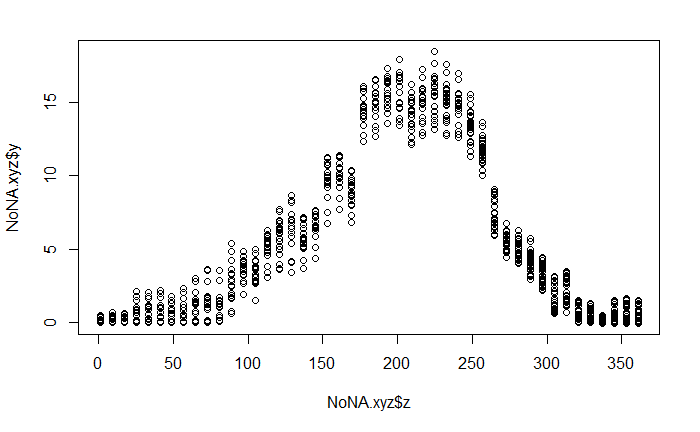

```r
  plot(NoNA.xyz$z, NoNA.xyz$y)
```

Plot some reaches to take a peek

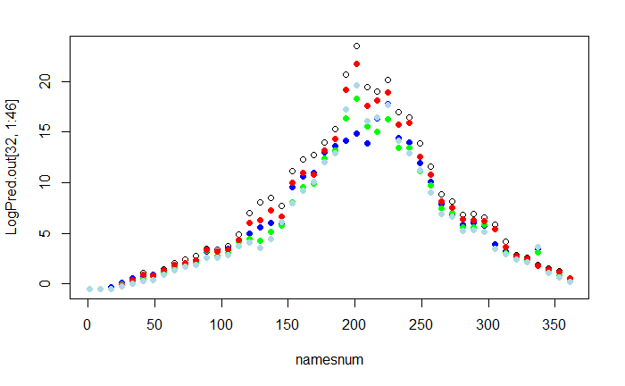

```r
  {plot(namesnum, LogPred.out[32,1:46])
  points(namesnum, LogPred.out[10, 1:46], pch=16, col="blue")
  points(namesnum, LogPred.out[75, 1:46], pch=16, col="green")
  points(namesnum, LogPred.out[141, 1:46], pch=16, col="red")
  points(namesnum, LogPred.out[150, 1:46], pch=16, col="lightblue")}
```

```r
NA
```

This parts formats the error by day/site info

```r
  Log.in <- read.csv(paste0("../../", basin, "_logger_8D_", yearPath, ".csv"), stringsAsFactors = FALSE)


  Pred.in <- read.dbf(paste0("predt", yearPath, "_", basin, "_8D_", var, ".dbf"))
  colnames(Pred.in)<-gsub(varName, "", colnames(Pred.in))
  colnames(Pred.in)<-gsub("_", "", colnames(Pred.in))
  newnamesnum <- as.numeric(colnames(Pred.in)[1:46]);

  Pred.Log.out <- data.frame (mup = NULL)
  SiteID <- unique(Log.in$SiteName)
    for (i in SiteID)
      {
        Log.site <- Log.in[Log.in$SiteName  == i,]
        Log.site <- as.data.frame(Log.site)


        RCAID <- ID.in$RCAID[ID.in$SiteName == i]

        Pred.site <- matrix(ncol=2, nrow=46)
        Pred.site[,1] <- as.numeric(unlist(colnames(Pred.in)[1:46]))
        Pred.site[,2] <- unlist(Pred.in[Pred.in$RCAID == RCAID, 1:46])
        Pred.site <- data.frame(Pred.site)
        colnames(Pred.site) <- c("JulDay", "Pred")

        Pred.Log.site <- merge(Pred.site, Log.site, by.x = "JulDay",by.y = "JulDay", all.x=TRUE, all.y = FALSE)

        Pred.Log.out <- rbind(Pred.Log.out, Pred.Log.site)
      }
```

```r
  ind <- apply(Pred.Log.out, 1, function(x) !any(is.na(x)))
  NoNA.pred <- Pred.Log.out[ind,]

  NoNA.pred <- NoNA.pred[,c(dataVar, "Pred", "JulDay", "SiteName")]
  colnames(NoNA.pred)[1] <- c("Obs")

  SiteID <- unique(NoNA.pred$SiteName)
  SiteID <- as.matrix(SiteID)
  Error.pts.out <- matrix(nrow = length(SiteID), ncol = 47)

  errorName <- paste0("JulDay_", namesnum)
  colnames(Error.pts.out)[2:47] <- errorName
  colnames(Error.pts.out)[1] <- "SiteName"

  Error.pts.out[1:length(SiteID), 1] <- unlist(SiteID)[1:length(SiteID)]
  Error.pts.out <- as.data.frame(Error.pts.out, stringsAsFactors = FALSE)
    for (i in SiteID)
      {
        error.site <- NoNA.pred[NoNA.pred$SiteName  == i,]
        error.site$error <- error.site[,'Obs']-error.site[,'Pred']


        error <- matrix(ncol=1, nrow=46)
        error[,1] <- namesnum
        error <- data.frame(error)
        colnames(error) <- c("JulDay")

        error.site.fill <- merge(error, error.site, by = "JulDay", all.x=TRUE, all.y = FALSE)
        Error.pts.out[Error.pts.out$SiteName==i,2:47] <- as.numeric(unlist(error.site.fill$error))
      }
  Error.pts.out[,2:47] <- sapply(Error.pts.out[,2:47], as.numeric)

  Error.pts.out[,2:47] <- round(Error.pts.out[,2:47], digits=3)
write.dbf(Error.pts.out, file = paste0("Error", yearPath, "_", basin, "_8D_", var, ".dbf"))
write.csv(Error.pts.out, file = paste0("Error", yearPath, "_", basin, "_8D_", var, ".csv"), row.names = FALSE)
```

Geospatial data output

```r
  gisPath <- paste0("D:/OneDrive/work/research/CHaMP/GIS/coverages/", midBasin)

  netname <- paste0(basin, "_STHD_net")
  ptsname <- paste0(longBasin, "_CHaMP_sites_all_years")

  error_pts <- readOGR(dsn=gisPath, layer = ptsname)
  error_pts@data <- error_pts@data[,c(3,9)]

  network <- readOGR(dsn=gisPath, layer = netname)
  error_pts <- spTransform(error_pts, proj4string(network))

  error_pts <- merge(error_pts, Error.pts.out, by="SiteName")
  network <- merge(network, LogPred.out, by = "RCAID")

  outnetname <- paste0(basin, "_", yearPath, "_8D_", var)
  outptsname <- paste0(basin, "_Error_", yearPath, "_8D_", var)

  writeOGR(obj=error_pts, dsn=".", layer = paste0(outptsname), driver="ESRI Shapefile", overwrite_layer = TRUE)
  writeOGR(obj=network, dsn=".", layer = paste0(outnetname), driver="ESRI Shapefile", overwrite_layer = TRUE)
```

Animation output

```r
  seis = c("#AA0000", "#D00000", "#F70000", "#FF1D00", "#FF4400", "#FF6A00", "#FF9000", "#FFB700", "#FFDD00", "#FFE200", "#BDFF0C", "#73FF1A", "#3FFA36", "#16F45A", "#00D08B", "#0087CD", "#0048FA", "#0024E3")
  seis <- rev(seis)

  names.out <- colnames(network@data[3:48])
  namesnum <- as.numeric(gsub(paste0("T", var, yrPath, "_"), "", colnames(network@data[3:48])))
  means <- colMeans(network@data[3:48], na.rm = TRUE)
  SDs <- colStdevs(network@data[3:48], na.rm = TRUE)
  yplus <- means + SDs
  yminus <- means - SDs
  df <- data.frame(means=means, SDs=SDs, names=namesnum)
  sequ <- c(1:46)
  namer <- sprintf('%03d', sequ)
  fix4 <- classIntervals(means, n = 10, style = "fixed",fixedBreaks=c(-1,2,4,6,8,10,12,14,16,18))
```

```
variable range greater than fixedBreaks
```

```r
  fix4.colors <- findColours(fix4,pal=seis)

  for (i in 3:48)
    {

      namey <- gsub(paste0("T", var, yrPath, "_"), "", colnames(network@data)[i])

      filename <- paste0(modelPath, "/graphics/", namer[i-2], ".png", sep="")
      png(filename=filename, res = 300, width = 1500, height = 1500, units = "px", bg="black")

       u <- unique(network@data[,i])

      if(length(u )< 3){
        fix3.colors <- rep("#0024E3",282)
      } else {
      fix3 <- classIntervals(network@data[,i], n = 11, style = "fixed",fixedBreaks=c(-1,2,4,6,8,10,12,14,16,18,20))
      fix3.colors <- findColours(fix3,pal=seis)
      }

      cexEr <-ifelse(abs(error_pts@data[,i]) == 0, 0,
                     ifelse(abs(error_pts@data[,i])>0 & error_pts@data[,i-1]<1, 0.5,
                            ifelse(abs(error_pts@data[,i])>1 & error_pts@data[,i-1]<2, 0.75,
                                   ifelse(abs(error_pts@data[,i])>2 & error_pts@data[,i-1]<3, 1.0,
                                          ifelse(abs(error_pts@data[,i])>3, 1.25,
                                                 ifelse(abs(error_pts@data[,i])== NA, 0, NA))))))

      plot(network, col=fix3.colors, bg="black", fg="white")
      points(error_pts, pch=16, col="gray40", cex=cexEr)

      legend("topleft", fill =  c("#0024E3","#0087CD","#16F45A","#73FF1A","#FFE200","#FFB700","#FF6A00","#FF1D00","#D00000","#AA0000"), title="°C", legend = c("0-2","2-4","4-6","6-8","8-10","10-12","12-14","14-16","16-18","18+"), bty = "n", cex=.5, inset=c(.05,0.1), text.col="white");
      legend("bottomleft", pch=16, col="gray40", pt.cex=c(0.5, 0.75, 1.0, 1.25), title="Model error (°C)", legend = c("0-1","1-2","2-3","3+"), bty = "n", cex=.5, inset=c(.05,0.1), text.col="white");


      title(paste0(longBasin, " 8-day ", longVar, " ", yearPath, " (°C)"), line=-0.6, adj=0.1, col.main="white", col.sub="white", outer=FALSE, cex.main=0.5)
        mtext(paste0("Julian Day ", namey),side =1, outer=TRUE, line=-5, col="white", cex=.5)

      tmp2 <- subplot(
        plot(namesnum[1:(i-2)], means[1:(i-2)], col=fix4.colors, pch=16, bty="n", xlim=c(0,360), ylim=c(0,20), cex.main=.8, main="Basin mean", adj=0, xlab='',ylab='', col.lab="white", cex.axis=0.5, cex.lab = 0.25, col.axis="white", col.main = "white", bg="black"),
        x=grconvertX(c(0.65,0.99), from='npc'),
        y=grconvertY(c(0.65, 0.85), from='npc'),
        size=c(1,1.5), vadj=0.5, hadj=0.5,
        pars=list( mar=c(0,0,0,0)+0.1, cex=0.5))

      op <- par(no.readonly=TRUE)
      par(tmp2)
      arrows(namesnum[1:(i-2)], yplus[1:(i-2)], namesnum[1:(i-2)], yminus[1:(i-2)], length=0, lwd=5, code=3, lend=0, col="gray20")
      par(op)
      tmp2 <- subplot(
        plot(namesnum[1:(i-2)], means[1:(i-2)], col=fix4.colors, pch=16, bty="n", xlim=c(0,360), ylim=c(0,20), cex.main=.8, main="Basin mean (+/-SD)", adj=0, xlab='',ylab='', col.lab="white", cex.axis=0.5, cex.lab = 0.25, col.axis="white", col.main = "white", bg="black"),
        x=grconvertX(c(0.65,0.99), from='npc'),
        y=grconvertY(c(0.65, 0.85), from='npc'),
        size=c(1,1.5), vadj=0.5, hadj=0.5,
        pars=list( mar=c(0,0,0,0)+0.1, cex=0.5))
      dev.off()
    }
```

[output not shown]

This system call builds an mpeg out of the still graphics

```r
setwd(paste0(modelPath, "/graphics/"))
```

```
The working directory was changed to D:/OneDrive/work/research/CHaMP/CHaMP_data/Secesh/2013/Max/graphics inside a notebook chunk. The working directory will be reset when the chunk is finished running. Use the knitr root.dir option in the setup chunk to change the the working directory for notebook …
```

```r
  system('"C:/Program Files/ImageMagick-7.0.1-Q16/convert.exe" -delay 20 -morph 3 *.png Sec_2013_8D_Mx.mpeg')
```

Still graphic output for wiki or web or wev

```r
  i <- 22
  namey <- gsub(paste0("T", var, "_", yrPath, "_"), "", colnames(network@data)[i])

    fix3 <- classIntervals(network@data[,i], n = 11, style = "fixed",fixedBreaks=c(-1,2,4,6,8,10,12,14,16,18, 20))
    fix3.colors <- findColours(fix3,pal=seis)

  filename <- paste0(modelPath, "/graphics/Stills/", basin, "_", yearPath, "_8D_", var, ".png", sep="")
    png(filename=filename, res = 300, width = 1500, height = 1500, units = "px", bg="white")

        cexEr <- ifelse(abs(error_pts@data[,i]) <= 1, 0.5,
                        ifelse(abs(error_pts@data[,i])>1, 0.75,
                               ifelse(abs(error_pts@data[,i])>2, 1.0,
                                      ifelse(abs(error_pts@data[,i])>3, 1.25, NA))))

        plot(network, col=fix3.colors, bg="white", fg="black")
        points(error_pts, pch=16, col="gray40", cex=cexEr)

        legend("topright", fill = attr(fix3.colors, "palette"), title="8-day Max (°C)",legend = c("0-6","6-8","8-10","10-12","12-14","14-16","16-18","18-20", "20-22", "22+"), bty = "n", cex=.5, inset=c(0,0), text.col="black");
        legend("bottomright", pch=16, col="gray40", pt.cex=c(0.5, 0.75, 1.0, 1.25), title="Model error (°C)", legend = c("0-1","1-2","2-3","3+"), bty = "n", cex=.5, inset=c(0,0), text.col="black");

        mtext(paste0(basin, " ",  yearPath, " 8-day ", var, " (°C)"),side =3, outer=TRUE, line=-3, col="black", cex=.7)
        mtext(paste0("Julian Day ", namey),side =1, outer=TRUE, line=-3, col="black", cex=.7)

        tmp2 <- subplot(
          plot(namesnum[1:(i-2)], means[1:(i-2)], col=fix4.colors, pch=16, bty="n", xlim=c(0,360), ylim=c(0,22), cex.main=.8, main="Basin mean", adj=0, xlab='',ylab='', col.lab="black", cex.axis=0.5, cex.lab = 0.25, col.axis="black", col.main = "black", bg="white"),
          x=grconvertX(c(0.0,0.25), from='npc'),
          y=grconvertY(c(0.80,0.95), from='npc'),
          size=c(1,1.5), vadj=0.5, hadj=0.5,
          pars=list( mar=c(0,0,0,0)+0.1, cex=0.5))
```

This part generates the project.rs.xml file

```r
Realizguid = UUIDgenerate(F)
now <- Sys.Date()
```

Start writing project.rs.xml file here

```r
cat("", file=paste(modelPath,"project.rs.xml",sep=""))
cat(paste("","<?xml version=\"1.0\" encoding=\"utf-8\"?>
<Project xmlns:xsi=\"http://www.w3.org/2001/XMLSchema-instance\"
  xsi:noNamespaceSchemaLocation=\"https://raw.githubusercontent.com/Riverscapes/Program/master/Project/XSD/V1/Project.xsd\">
  <Name>stream_temperature_project</Name>
  <ProjectType>STREAMTEMP",capVar,"</ProjectType>
  <MetaData>
    <!--This first metadata exists only to place this project in the riverscapes project-->
    <Meta name=\"HUCID\">17060201</Meta>
        <Meta name=\"Region\">CRB</Meta>
    <Meta name=\"Watershed\">",nameBasin,"</Meta>
    <Meta name=\"Year\">", yearPath,"</Meta>
  </MetaData>

  <Inputs>
  </Inputs>
  <Realizations>
    <StreamTemperature guid=\"",Realizguid,"\" id=\"streamtemp\" dateCreated=\"",now,"\" productVersion=\"1.0\">
      <Name>Stream Temperature for ",nameBasin, " ",yearPath,"</Name>
      <MetaData>
        <!--This next metadata relates to this particular realization-->
        <Meta name=\"MODIS_dataset\">MOD11A2v005</Meta>
        <Meta name=\"EOSDIS\">https://reverb.echo.nasa.gov/reverb/</Meta>
        <Meta name=\"Logger_data_source\">www.champmonitoring.org</Meta>
        <Meta name=\"Code_wiki\">https://github.com/SouthForkResearch/StreamTemperature/wiki</Meta>
      </MetaData>
      <Analyses>
        <Analysis>
          <Name>Stream Temp Analysis</Name>
          <Outputs>
            <CSV id=\"coeffs\">
              <Name>Model_coefficients</Name>
              <Path>All_data_",basin,"_",yearPath,"_mod_coeffs_",var,".csv</Path>
              <MetaData>
                <Meta name=\"description\">Parameter coefficients for the final model</Meta>
              </MetaData>
            </CSV>
            <CSV id=\"metrics\">
              <Name>Model_metrics</Name>
              <Path>All_data_",basin,"_",yearPath,"_mod_metrics_",var,".csv</Path>
              <MetaData>
                <Meta name=\"description\">Model quality metrics</Meta>
              </MetaData>
            </CSV>
            <CSV id=\"error\">
              <Name>Model_error</Name>
              <Path>Error_",basin,"_",yearPath,"_8D_",var,".csv</Path>
              <MetaData>
                <Meta name=\"description\">Model estimation error for each 8-day period by site</Meta>
              </MetaData>
            </CSV>
            <CSV id=\"estimates\">
              <Name>Model_data_prediction</Name>
              <Path>jk_pred_v_y_",var, "_", basin,"_",yearPath,"_sp_fall.csv</Path>
              <MetaData>
                <Meta name=\"description\">Jack-knifed temperature estimate for each 8-day logger input</Meta>
              </MetaData>
            </CSV>
            <CSV id=\"modelData\">
              <Name>Model_input_data</Name>
              <Path>", basin,"_",yearPath,"_8Day_",var,"_model_data.csv</Path>
              <MetaData>
                <Meta name=\"description\">Formatted input data used in the model</Meta>
              </MetaData>
            </CSV>

            <Image id=\"still\">
              <Name>Network_estimate_snapshot</Name>
              <Path>graphics/Stills/",basin,"_",yearPath,"_8D_",var,".png</Path>
              <MetaData>
                <Meta name=\"description\">Still image of estimated temperature and error-by-site on the network for one day</Meta>
              </MetaData>
            </Image>
            <Video id=\"movie\">
              <Name>Network_annual_estimate_animation</Name>
              <Path>graphics/",basin,"_",yearPath,"_8D_",var,".mpeg</Path>
            </Video>
            <Vector id=\"network\">
              <Name>Network_estimate_shapefile</Name>
              <Path>",basin,"_",yearPath,"_8D_",var,".shp</Path>
              <MetaData>
                <Meta name=\"description\">Shapefile of network with temperature estimates for each 8-day period</Meta>
              </MetaData>
            </Vector>
            <Vector id=\"errorPts\">
              <Name>Error_by_site_points</Name>
              <Path>",basin,"_Error_",yearPath,"_8D_",var,".shp</Path>
              <MetaData>
                <Meta name=\"description\">Point shapefile of all included sites with model estimation error</Meta>
              </MetaData>
            </Vector>
          </Outputs>
        </Analysis>
      </Analyses>
    </StreamTemperature>
  </Realizations>
</Project>
",sep=""), file=paste(modelPath,"project.rs.xml",sep=""), append=T)
```